# R Notebook

```r
rm(list = ls())
root_dir <- rprojroot::find_rstudio_root_file()
setwd(root_dir)
source("./scripts/rawdata2.R")
```

```
  % Total    % Received % Xferd  Average Speed   Time    Time     Time  Current
                                 Dload  Upload   Total   Spent    Left  Speed

  0     0    0     0    0     0      0      0 --:--:-- --:--:-- --:--:--     0
  0     0    0     0    0     0      0      0 --:--:-- --:--:-- --:--:--     0
100 19.6M    0 19.6M    0     0  32.9M      0 --:--:-- --:--:-- --:--:-- 32.9M
```

```r
source("./scripts/plot.roots.R")
```

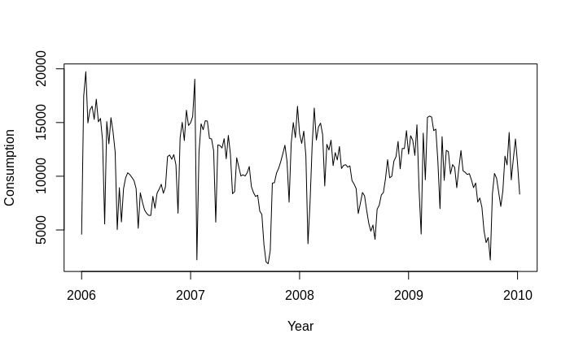

```r
# install.packages(c("xts","zoo","forecast","qpcR","astsa","TSA"))
library(xts)
library(zoo)
data$Date <- as.Date(data$Date, format="%d/%m/%Y")
data <- na.omit(data)
data$Global_active_power <- as.numeric(data$Global_active_power)

# Get weekly consumption
# "%Y-%U" gives the year and week number
weekly_data <- aggregate(Global_active_power ~ format(Date, "%Y-%W"), data, sum)
colnames(weekly_data) <- c("YearWeek", "Global_active_power")

# Convert the YearWeek to a Date object representing the first day of each week
weekly_data$Week_Start <- as.Date(paste(weekly_data$YearWeek, 1), format="%Y-%U %u")
# Setting up timeseries with frequency = 12
power_ts <- ts(weekly_data$Global_active_power, start=c(2006, which(weekdays(as.Date("2006-01-01")) == "Sunday")), frequency=52)
ts.plot(power_ts, gpars=list(xlab="Year", ylab="Consumption"))
```

```r
fit <- lm(power_ts ~ time(power_ts))
ts.plot(power_ts,gpars=list(xlab="Year",ylab="Consumption"))
abline(h=mean(power_ts), col="red")
```

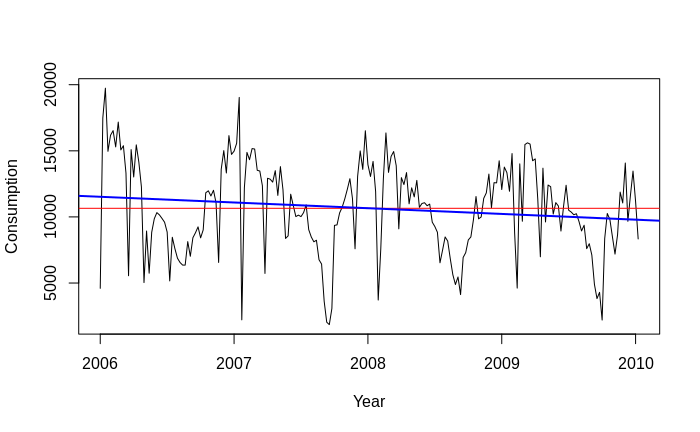

```r
abline(fit, col="blue", lwd=2)
```

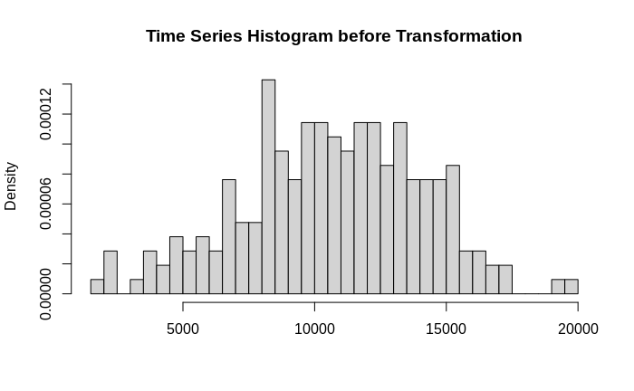

```r
hist(power_ts, breaks = 40, xlab="", prob=TRUE,
main = 'Time Series Histogram before Transformation')
```

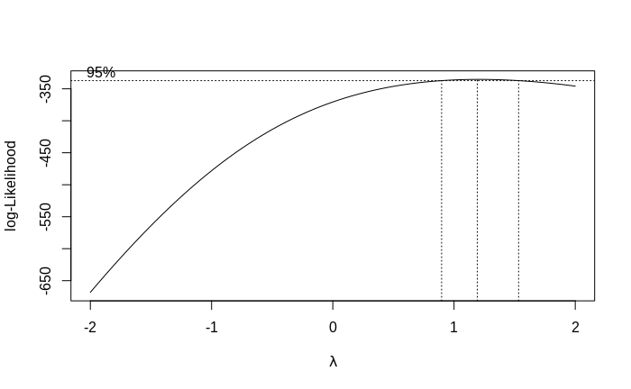

```r
library(MASS)
t = 1:length(power_ts)
fit = lm(power_ts ~ t)
bcTransform = boxcox(power_ts ~ t,plotit = TRUE)
```

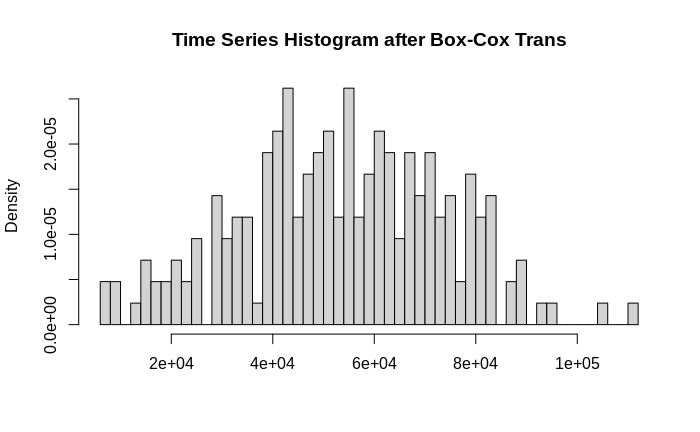

```r
lambda = bcTransform$x[which(bcTransform$y == max(bcTransform$y))]
power_ts.bc = (1/lambda)*(power_ts^lambda-1)
hist(power_ts.bc, breaks = 40, xlab="", prob=TRUE,
main = 'Time Series Histogram after Box-Cox Trans')
```

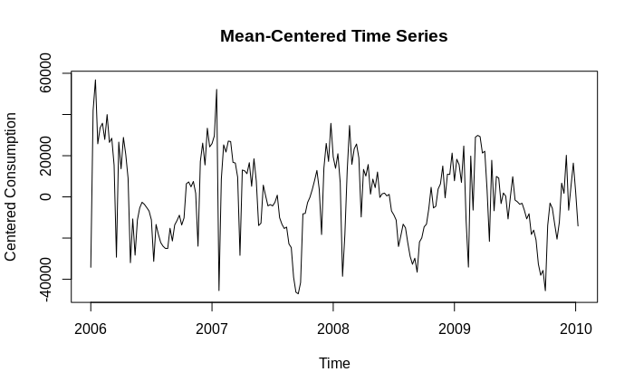

```r
# Assuming power_ts is your original time series object
mean_power_ts.bc <- mean(power_ts.bc)

# Subtract the mean from the time series to center it
power_ts.bc <- power_ts.bc - mean_power_ts.bc

# Now you can proceed with your time series analysis on the centered data
# For example, plotting the centered time series
plot(power_ts.bc, main="Mean-Centered Time Series", xlab="Time", ylab="Centered Consumption")
```

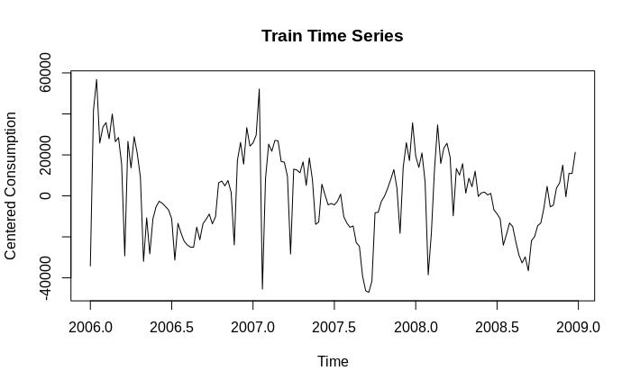

```r
# Find the index that corresponds to mid-2009
cut_off <- which(time(power_ts.bc) >= as.yearmon("2009-06"))
# Split the data into training and test sets
train_set <- window(power_ts.bc, end=c(2009, (which.max(time(power_ts.bc) < as.yearmon("2009-07")))/frequency(power_ts.bc)))
test_set <- window(power_ts.bc, start=c(2009, (which.min(time(power_ts.bc) >= as.yearmon("2009-07")))/frequency(power_ts.bc)))
plot(train_set, main="Train Time Series", xlab="Time", ylab="Centered Consumption")
```

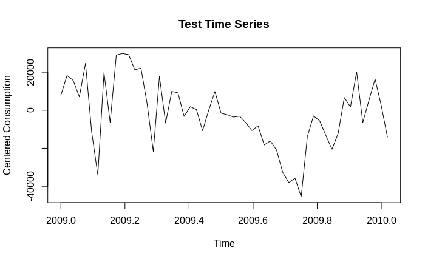

```r
plot(test_set, main="Test Time Series", xlab="Time", ylab="Centered Consumption")
```

```r
shapiro.test(train_set)
```

```
    Shapiro-Wilk normality test

data:  train_set
W = 0.9936, p-value = 0.7238
```

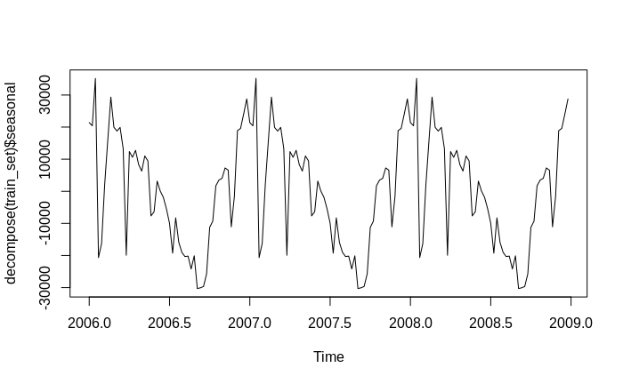

```r
plot(decompose(train_set)$seasonal)
```

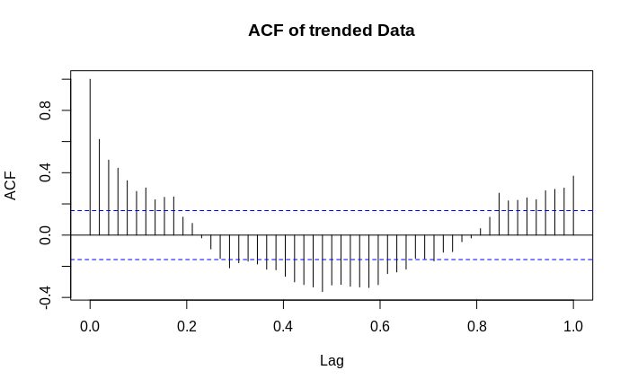

```r
train_set_diff <- diff(train_set, 1)
acf(train_set, lag.max = 52, main = 'ACF of trended Data') # ACF
```

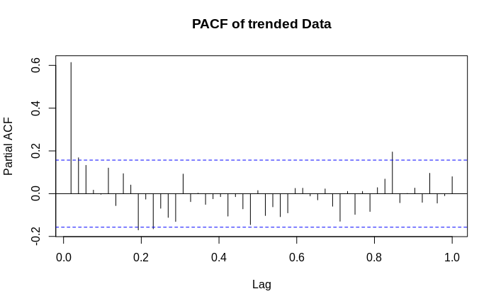

```r
pacf(train_set, lag.max = 52, main = 'PACF of trended Data') # PACF
```

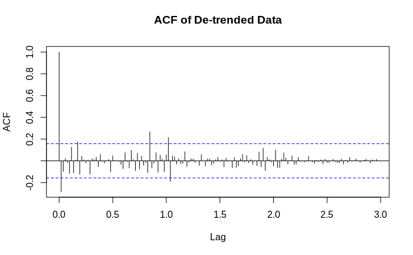

```r
acf(train_set_diff, lag.max = 52*3, main = 'ACF of De-trended Data') # ACF
```

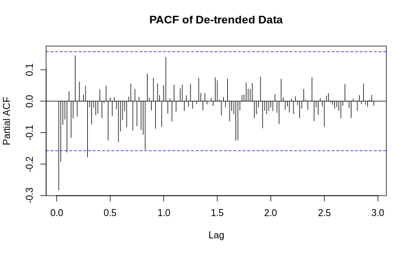

```r
pacf(train_set_diff, lag.max = 52*3, main = 'PACF of De-trended Data') # PACF
```

```r
library(tseries)

max_diff <- 10  # Set a maximum number of differences
variances <- numeric(max_diff)
p_values <- numeric(max_diff)

for (i in 1:max_diff) {
  if (i == 1) {
    differenced_ts <- diff(train_set, differences = 1)
  } else {
    differenced_ts <- diff(differenced_ts, differences = 1)
  }

  variances[i] <- var(differenced_ts)
  adf_test <- adf.test(differenced_ts, alternative = "stationary")
  p_values[i] <- adf_test$p.value

  # Print the variance and the ADF test p-value
  cat("Differencing level", i, ": Variance =", variances[i], ", p-value =", p_values[i], "\n")

  # Optional: Stop if p-value is below a certain threshold, e.g., 0.05
  if (p_values[i] < 0.05) {
    cat("Stationarity achieved at differencing level", i, "\n")
    break
  }
}
```

```
Differencing level 1 : Variance = 328872423 , p-value = 0.01
Stationarity achieved at differencing level 1
```

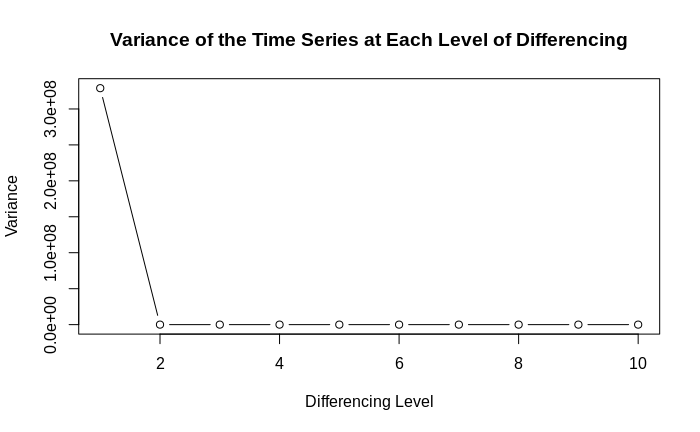

```r
# Plotting the variance
plot(variances, type = "b", xlab = "Differencing Level", ylab = "Variance",
     main = "Variance of the Time Series at Each Level of Differencing")
```

```r
var(train_set) # Variance before Diff
```

```
[1] 436751091
```

```r
dt.train_set <- diff(train_set, 1)
(var(dt.train_set)) # Variance after diff once at lag 1
```

```
[1] 328872423
```

```r
dt2.train_set <- diff(dt.train_set, 52)
(var(dt2.train_set)) # Variance after diff twice at lag 52 seasonal trend
```

```
[1] 655441677
```

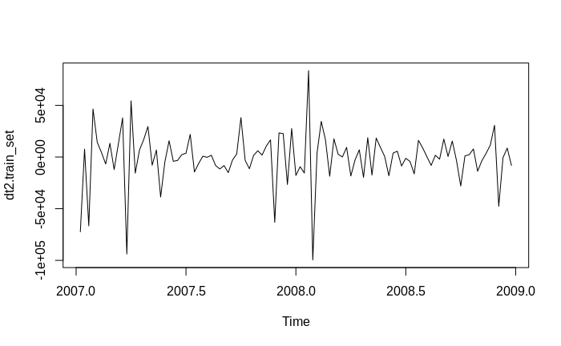

```r
plot(dt2.train_set) # Plot of the de-trended data
```

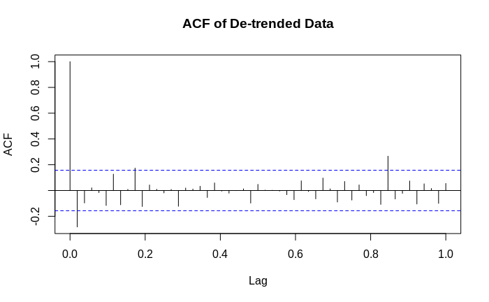

```r
train_set_diff <- diff(train_set, 1)
acf(train_set_diff, lag.max = 52, main = 'ACF of De-trended Data') # ACF
```

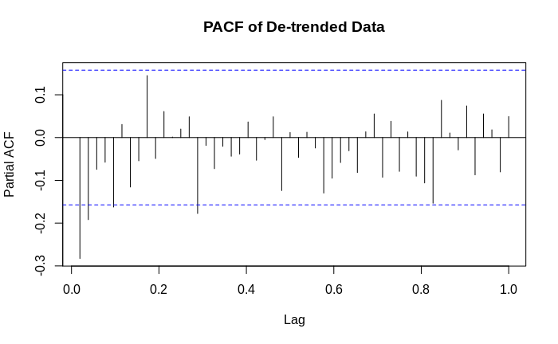

```r
pacf(train_set_diff, lag.max = 52, main = 'PACF of De-trended Data') # PACF
```

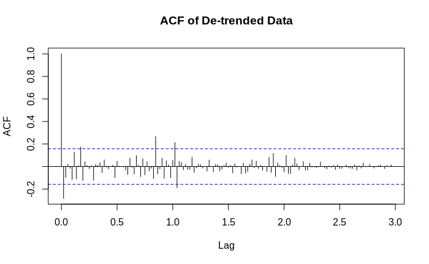

```r
acf(train_set_diff, lag.max = 52*3, main = 'ACF of De-trended Data') # ACF
```

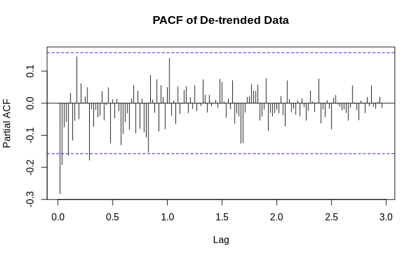

```r
pacf(train_set_diff, lag.max = 52*3, main = 'PACF of De-trended Data') # PACF
```

```r
# Compute ACF and PACF
acf_values <- acf(train_set_diff, lag.max = 52*3, plot = FALSE)
pacf_values <- pacf(train_set_diff, lag.max = 52*3, plot = FALSE)

# Determine the significance level (95% confidence)
n <- length(train_set_diff)
conf_level <- qnorm((1 + 0.95)/2) / sqrt(n)

# Find significant lags for ACF
significant_acf_lags <- which(abs(acf_values$acf) > conf_level)

# Find significant lags for PACF
significant_pacf_lags <- which(abs(pacf_values$acf) > conf_level)

# Output the lags
cat("Significant ACF lags at 95% confidence: ", significant_acf_lags, "\n")
```

```
Significant ACF lags at 95% confidence:  1 2 10 45 54 55
```

```r
cat("Significant PACF lags at 95% confidence: ", significant_pacf_lags, "\n")
```

```
Significant PACF lags at 95% confidence:  1 2 5 15 43
```

When determining the period for a seasonal model from ACF and PACF plots, I consider the domain knowledge about the data as well as the repeating patterns in the lags. The significant lags provided suggest there is a significant autocorrelation at lags 1, 2, 10, 45, 54, 55.

The lag values of 54 and 55 suggest a possible yearly seasonality (assuming the data is weekly, as 52 weeks is approximately one year). Since the significant lag at 54 is close to 52 and appears to be a prominent seasonal peak, it could be the actual seasonal period, especially if it matches with domain knowledge or expected seasonal patterns in the data.

Here’s why I choose 52 over 54:

```
52 weeks in a year: There are 52 full weeks in a year, which is a common period for weekly data when considering annual seasonality.
Data alignment: The data may not align perfectly with calendar years, and some years may include an extra day or two due to leap years. This can slightly shift the seasonal peaks in the ACF.
Natural Periodicity: Many natural, economic, and social cycles follow an annual pattern, reinforcing the choice of 52 weeks.
```

In practice, I would typically choose 52 as the period for weekly data unless there is a compelling reason based on the data or domain knowledge to choose a slightly different period like 54. Before finalizing the period, it’s recommended to plot the data and look for seasonal patterns that align with these lags, and to validate the seasonality with domain expertise.

p: 0,1,2,10,45 q: 0,1,2,5,15,43 d: 1 P: 0 Q: 0,1 D: 0 s:52

```r
library(forecast)
library(qpcR)

# Initialize an empty list to store AICc values and model specifications
aiccs <- list()
model_saver <- list()

# Loop over the candidate variables for p, q, and Q
for(p in c(0,1,2,10)) {
  for(q in c(0,1,2,5,15,43)) {
    for(Q in c(0, 1)) {
      # Fit the arima model with the given parameters
      model <- Arima(train_set, order=c(p, 1, q), seasonal=c(0, 0, Q), method="ML")
      model_saver[[paste("p=", p, "q=", q, "Q=", Q, sep="")]] <- model
      # Calculate the AICc and store in the list with the corresponding model specifications
      aiccs[[paste("p=", p, "q=", q, "Q=", Q, sep="")]] <- AICc(model)
    }
  }
}

# Display the AICc values and corresponding model specifications
aiccs
```

```
$`p=0q=0Q=0`
[1] 3480.661

$`p=0q=0Q=1`
[1] 3481.981

$`p=0q=1Q=0`
[1] 3457.588

$`p=0q=1Q=1`
[1] 3455.397

$`p=0q=2Q=0`
[1] 3456.131

$`p=0q=2Q=1`
[1] 3454.53

$`p=0q=5Q=0`
[1] 3461.285

$`p=0q=5Q=1`
[1] 3459.923

$`p=0q=15Q=0`
[1] 3458.56

$`p=0q=15Q=1`
[1] 3456.212

$`p=0q=43Q=0`
[1] 3514.751

$`p=0q=43Q=1`
[1] 3513.579

$`p=1q=0Q=0`
[1] 3468.087

$`p=1q=0Q=1`
```

[output cut: 88 more lines]

```

$`p=10q=5Q=1`
[1] 3458.247

$`p=10q=15Q=0`
[1] 3475.176

$`p=10q=15Q=1`
[1] 3472.056

$`p=10q=43Q=0`
[1] 3543.678

$`p=10q=43Q=1`
[1] 3550.245
```

```r
# Merge the lists
all_aiccs <- c(aiccs)

print(all_aiccs)
```

```
$`p=0q=0Q=0`
[1] 3480.661

$`p=0q=0Q=1`
[1] 3481.981

$`p=0q=1Q=0`
[1] 3457.588

$`p=0q=1Q=1`
[1] 3455.397

$`p=0q=2Q=0`
[1] 3456.131

$`p=0q=2Q=1`
[1] 3454.53

$`p=0q=5Q=0`
[1] 3461.285

$`p=0q=5Q=1`
[1] 3459.923

$`p=0q=15Q=0`
[1] 3458.56

$`p=0q=15Q=1`
[1] 3456.212

$`p=0q=43Q=0`
[1] 3514.751

$`p=0q=43Q=1`
[1] 3513.579

$`p=1q=0Q=0`
[1] 3468.087

$`p=1q=0Q=1`
```

[output cut: 88 more lines]

```

$`p=10q=5Q=1`
[1] 3458.247

$`p=10q=15Q=0`
[1] 3475.176

$`p=10q=15Q=1`
[1] 3472.056

$`p=10q=43Q=0`
[1] 3543.678

$`p=10q=43Q=1`
[1] 3550.245
```

```r
# Convert the list to a named vector
aiccs_vector <- unlist(all_aiccs)

# Sort the vector in ascending order of AICc values
sorted_aiccs <- sort(aiccs_vector)

# Get the names of the top five models
top_ten_names <- names(head(sorted_aiccs, 10))

# Get the AICc values of the top five models
top_ten_values <- head(sorted_aiccs, 10)

# Print the top five models with their AICc values
for (i in 1:10) {
    cat("Model:", top_ten_names[i], "with an AICc of", top_ten_values[i], "\n")
}
```

```
Model: p=2q=5Q=1 with an AICc of 3450.743
Model: p=2q=5Q=0 with an AICc of 3452.184
Model: p=1q=1Q=1 with an AICc of 3454.3
Model: p=0q=2Q=1 with an AICc of 3454.53
Model: p=1q=15Q=1 with an AICc of 3455.325
Model: p=0q=1Q=1 with an AICc of 3455.397
Model: p=1q=1Q=0 with an AICc of 3456.117
Model: p=0q=2Q=0 with an AICc of 3456.131
Model: p=0q=15Q=1 with an AICc of 3456.212
Model: p=1q=2Q=1 with an AICc of 3456.39
```

```r
Arima(train_set_diff, order=c(9, 1, 10), seasonal=c(0, 0, 1), method="ML")
```

```
Series: train_set_diff
ARIMA(9,1,10)(0,0,1)[52]

Coefficients:
```

```
          ar1      ar2     ar3      ar4      ar5      ar6      ar7      ar8    ar9     ma1      ma2      ma3     ma4     ma5    ma6      ma7      ma8     ma9    ma10    sma1
      -1.2233  -1.0713  -0.734  -0.7748  -0.9297  -1.2083  -0.9199  -0.4363  3e-04  -0.221  -0.4068  -0.3061  0.2736  0.0015  0.413  -0.5906  -0.4240  0.0573  0.2073  0.2296
s.e.      NaN      NaN     NaN      NaN      NaN      NaN      NaN      NaN    NaN   0.005      NaN      NaN  0.0073  0.0040    NaN      NaN   0.0015  0.0039     NaN     NaN

sigma^2 = 254675944:  log likelihood = -1704.25
AIC=3450.51   AICc=3457.51   BIC=3514.28
```

```r
# Loop through each model in the list and print its summary
for (model_name in top_ten_names) {
  cat("\nSummary for model:", model_name, "\n")
  print(summary(model_saver[[model_name]]))
}
```

```
Summary for model: p=2q=5Q=1
Series: train_set
ARIMA(2,1,5)(0,0,1)[52]

Coefficients:
          ar1     ar2     ma1     ma2      ma3      ma4      ma5    sma1
      -1.2083  -0.728  0.7813  0.0285  -0.5585  -0.1157  -0.2019  0.2006
s.e.   0.1324   0.240  0.1581  0.2362   0.1440   0.1482   0.1082  0.1103

sigma^2 = 247839000:  log likelihood = -1715.88
AIC=3449.76   AICc=3451.01   BIC=3477.15

Training set error measures:
                   ME     RMSE      MAE      MPE     MAPE      MASE      ACF1
Training set 298.5712 15282.04 10578.31 32.57319 157.3112 0.7525628 0.0468236

Summary for model: p=2q=5Q=0
Series: train_set
ARIMA(2,1,5)

Coefficients:
          ar1      ar2     ma1     ma2      ma3      ma4      ma5
      -1.2441  -0.7903  0.8584  0.1109  -0.5567  -0.1257  -0.1744
s.e.   0.1137   0.1182  0.1375  0.1429   0.1202   0.1278   0.1033

sigma^2 = 255499123:  log likelihood = -1717.71
AIC=3451.43   AICc=3452.41   BIC=3475.77

Training set error measures:
                   ME     RMSE      MAE      MPE     MAPE      MASE       ACF1
Training set 366.5532 15569.09 10952.27 33.21348 166.2681 0.7791672 0.05132073

Summary for model: p=1q=1Q=1
Series: train_set
ARIMA(1,1,1)(0,0,1)[52]

Coefficients:
         ar1      ma1    sma1
      0.2505  -0.7582  0.2007
s.e.  0.1374   0.0912  0.1029
```

[output cut: 104 more lines]

```
Summary for model: p=1q=2Q=1
Series: train_set
ARIMA(1,1,2)(0,0,1)[52]

Coefficients:
         ar1      ma1     ma2    sma1
      0.3303  -0.8401  0.0526  0.2019
s.e.  0.5902   0.6025  0.3859  0.1032

sigma^2 = 267370798:  log likelihood = -1723.06
AIC=3456.12   AICc=3456.53   BIC=3471.34

Training set error measures:
                   ME    RMSE      MAE      MPE     MAPE      MASE       ACF1
Training set 360.0585 16087.3 10545.24 17.02172 144.0282 0.7502101 0.05314998
```

```r
refine_models <- list()
library(astsa)

# Model 1: ARIMA(2,1,5)(0,0,1)[52]
refine_models[['p=2q=5Q=1']] <- arima(train_set, order=c(2, 1, 5), seasonal=c(0, 0, 1), fixed= c(NA,    NA, NA, 0,  NA, 0,  NA, NA), method="ML")
# Model 2: ARIMA(2,1,5)
refine_models[['p=2q=5Q=0']] <- arima(train_set, order=c(2, 1, 5), seasonal=c(0, 0, 0),fixed=c(NA,  NA, NA, 0,  NA, 0,  NA), method="ML")

# Model 3: ARIMA(1,1,1)(0,0,1)[52]
refine_models[['p=1q=1Q=1']] <- arima(train_set, order=c(1, 1, 1), seasonal=c(0, 0, 1),fixed=c(NA,  NA, NA), method="ML")

# Model 4: ARIMA(0,1,2)(0,0,1)[52]
refine_models[['p=0q=2Q=1']] <- arima(train_set, order=c(0, 1, 2), seasonal=c(0, 0, 1),fixed=c(NA,  NA, NA), method="ML")

# Model 5: ARIMA(1,1,15)(0,0,1)[52]
refine_models[['p=1q=15Q=1']] <- arima(train_set, order=c(1, 1, 15), seasonal=c(0,0,1),fixed=c(NA,  NA, NA, NA, 0,  0,  0,  0,  NA, NA, 0,  0,  0,  0,  0,  NA, NA), method="ML")

# Model 6: ARIMA(0,1,1)(0,0,1)[52]
refine_models[['p=0q=1Q=1']] <- arima(train_set, order=c(0, 1, 1), seasonal=c(0, 0, 1),fixed=c(NA,  NA), method="ML")

# Model 7: ARIMA(1,1,1)
refine_models[['p=1q=1Q=0']] <- arima(train_set, order=c(1, 1, 1), seasonal=c(0, 0, 0),fixed=c(NA,  NA), method="ML")

# Model 8: ARIMA(0,1,2)
refine_models[['p=0q=2Q=0']] <- arima(train_set, order=c(0, 1, 2), seasonal=c(0, 0, 0),fixed=c(NA,  NA), method="ML")

# Model 9: ARIMA(0,1,15)(0,0,1)[52]
refine_models[['p=0q=15Q=1']] <- arima(train_set, order=c(0, 1, 15), seasonal=c(0, 0, 1),fixed=c(NA,    NA, 0,  0,  NA, NA, NA, 0,  NA, NA, 0,  0,  0,  0,  0,  NA), method="ML")


# Model 10: ARIMA(1,1,2)(0,0,1)[52]
refine_models[['p=1q=2Q=1']] <- arima(train_set, order=c(1, 1, 2), seasonal=c(0, 0, 1),fixed=c(NA,  NA, NA, NA), method="ML")
```

```r
# Loop through each model in the list and print its summary
for (model_name in top_ten_names) {
  cat("\nSummary for model:", model_name, "\n")
  print(summary(refine_models[[model_name]]))
}
```

```
Summary for model: p=2q=5Q=1

Call:
arima(x = train_set, order = c(2, 1, 5), seasonal = c(0, 0, 1), fixed = c(NA,
    NA, NA, 0, NA, 0, NA, NA), method = "ML")

Coefficients:
          ar1      ar2     ma1  ma2      ma3  ma4      ma5    sma1
      -1.1856  -0.6940  0.7412    0  -0.4809    0  -0.1577  0.1930
s.e.   0.1213   0.1148  0.1223    0   0.0986    0   0.0960  0.1003

sigma^2 estimated as 236804507:  log likelihood = -1716.36,  aic = 3446.72

Training set error measures:
                  ME     RMSE      MAE      MPE    MAPE      MASE       ACF1
Training set 342.333 15339.05 10492.75 29.97716 158.849 0.9204413 0.06830935

Summary for model: p=2q=5Q=0

Call:
arima(x = train_set, order = c(2, 1, 5), seasonal = c(0, 0, 0), fixed = c(NA,
    NA, NA, 0, NA, 0, NA), method = "ML")

Coefficients:
          ar1      ar2     ma1  ma2      ma3  ma4      ma5
      -1.1907  -0.7117  0.7649    0  -0.4991    0  -0.1318
s.e.   0.1230   0.1094  0.1183    0   0.0980    0   0.0994

sigma^2 estimated as 245914091:  log likelihood = -1718.25,  aic = 3448.5

Training set error measures:
                   ME     RMSE      MAE      MPE     MAPE      MASE       ACF1
Training set 381.8359 15631.31 11006.26 31.38026 172.0101 0.9654878 0.08903944

Summary for model: p=1q=1Q=1

Call:
arima(x = train_set, order = c(1, 1, 1), seasonal = c(0, 0, 1), fixed = c(NA,
    NA, NA), method = "ML")

```

[output cut: 114 more lines]

```

Call:
arima(x = train_set, order = c(1, 1, 2), seasonal = c(0, 0, 1), fixed = c(NA,
    NA, NA, NA), method = "ML")

Coefficients:
         ar1      ma1     ma2    sma1
      0.3303  -0.8401  0.0526  0.2019
s.e.  0.5902   0.6025  0.3859  0.1032

sigma^2 estimated as 260470898:  log likelihood = -1723.06,  aic = 3456.12

Training set error measures:
                   ME    RMSE      MAE      MPE     MAPE      MASE       ACF1
Training set 360.0585 16087.3 10545.24 17.02172 144.0282 0.9250463 0.05314998
```

```r
refine_models95 <- list()
library(astsa)

# Model 1: ARIMA(2,1,5)(0,0,1)[52]
refine_models95[['p=2q=5Q=1']] <- arima(train_set, order=c(2, 1, 5), seasonal=c(0, 0, 1), fixed= c(NA,  NA, NA, 0,  NA, 0,  0,  0), method="ML")

# Model 2: ARIMA(2,1,5)
refine_models95[['p=2q=5Q=0']] <- arima(train_set, order=c(2, 1, 5), seasonal=c(0, 0, 0),fixed=c(NA,    NA, NA, 0,  NA, 0,  0), method="ML")

# Model 3: ARIMA(1,1,1)(0,0,1)[52]
refine_models95[['p=1q=1Q=1']] <- arima(train_set, order=c(1, 1, 1), seasonal=c(0, 0, 1),fixed=c(0, NA, 0), method="ML")
# Model 4: ARIMA(1,1,15)(0,0,1)[52]
refine_models95[['p=1q=15Q=1']] <- arima(train_set, order=c(1, 1, 15), seasonal=c(0, 0, 1),fixed=c(NA,  NA, NA, NA, 0,  0,  0,  0,  NA, NA, 0,  0,  0,  0,  0,  0,  0), method="ML")

# Model 5: ARIMA(0,1,2)(0,0,1)[52]
refine_models95[['p=0q=2Q=1']] <- arima(train_set, order=c(0, 1, 2), seasonal=c(0, 0, 1),fixed=c(NA,    0,  0), method="ML")

# Model 6: ARIMA(1,1,1)
refine_models95[['p=1q=1Q=0']] <- arima(train_set, order=c(1, 1, 1), seasonal=c(0, 0, 0),fixed=c(NA,    NA), method="ML")

# Model 7: ARIMA(0,1,2)
refine_models95[['p=0q=2Q=0']] <- arima(train_set, order=c(0, 1, 2), seasonal=c(0, 0, 0),fixed=c(NA,    0), method="ML")

# Model 8: ARIMA(0,1,15)(0,0,1)[52]
refine_models95[['p=0q=15Q=1']] <- arima(train_set, order=c(0, 1, 15), seasonal=c(0, 0, 1),fixed=c(NA,  0,  0,  0,  NA, NA, NA, 0,  NA, NA, 0,  0,  0,  0,  0,  NA), method="ML")

# Model 9: ARIMA(0,1,1)(0,0,1)[52]
refine_models95[['p=0q=1Q=1']] <- arima(train_set, order=c(0, 1, 1), seasonal=c(0, 0, 1),fixed=c(NA,    0), method="ML")

# Model 10: ARIMA(1,1,15)
refine_models95[['p=1q=15Q=0']] <- arima(train_set, order=c(1, 1, 15), seasonal=c(0, 0, 0),fixed=c(NA,  NA, NA, 0,  0,  0,  0,  0,  0,  NA, 0,  NA, 0,  0,  0,  0), method="ML")
```

```r
# Loop through each model in the list and print its summary
for (model_name in top_ten_names) {
  cat("\nSummary for model:", model_name, "\n")
  print(summary(refine_models95[[model_name]]))
}
```

```
Summary for model: p=2q=5Q=1
```

[output not shown]

```r
# Loop through each model in the list and print its summary
for (model_name in top_ten_names) {
  cat("\nSummary for model:", model_name, "\n")
  print(AICc(refine_models[[model_name]]))
}
```

```
Summary for model: p=2q=5Q=1
[1] 3447.696

Summary for model: p=2q=5Q=0
[1] 3449.261

Summary for model: p=1q=1Q=1
[1] 3454.3

Summary for model: p=0q=2Q=1
[1] 3454.53

Summary for model: p=1q=15Q=1
[1] 3446.969

Summary for model: p=0q=1Q=1
[1] 3455.397

Summary for model: p=1q=1Q=0
[1] 3456.117

Summary for model: p=0q=2Q=0
[1] 3456.131

Summary for model: p=0q=15Q=1
[1] 3449.576

Summary for model: p=1q=2Q=1
[1] 3456.39
```

The candidate models for analysis are:

AICcs for model: p=1q=15Q=1 [1] 3446.969

AICcs for model: p=2q=5Q=1 [1] 3447.696

Summary for model: p=0q=15Q=1 [1] 3449.576

```r
candidates = c("p=1q=15Q=1","p=2q=5Q=1","p=0q=15Q=1")
candidate_model <- list()
for (model_name in candidates) {
  cat("\nSummary for model:", model_name, "\n")
  candidate_model[[model_name]] <- refine_models[[model_name]]
  print(summary(refine_models[[model_name]]))
}
```

```
Summary for model: p=1q=15Q=1

Call:
arima(x = train_set, order = c(1, 1, 15), seasonal = c(0, 0, 1), fixed = c(NA,
    NA, NA, NA, 0, 0, 0, 0, NA, NA, 0, 0, 0, 0, 0, NA, NA), method = "ML")

Coefficients:
          ar1     ma1      ma2      ma3  ma4  ma5  ma6  ma7      ma8     ma9  ma10  ma11  ma12  ma13  ma14     ma15    sma1
      -0.9580  0.4605  -0.7324  -0.3378    0    0    0    0  -0.1944  0.0915     0     0     0     0     0  -0.2467  0.2974
s.e.   0.0308  0.0981   0.0680   0.0915    0    0    0    0   0.0565  0.0674     0     0     0     0     0   0.0609  0.1063

sigma^2 estimated as 213861969:  log likelihood = -1712.27,  aic = 3442.53

Training set error measures:
                    ME     RMSE      MAE      MPE     MAPE      MASE       ACF1
Training set -565.8513 14577.07 10315.65 42.77896 136.4711 0.9049058 0.06201807

Summary for model: p=2q=5Q=1

Call:
arima(x = train_set, order = c(2, 1, 5), seasonal = c(0, 0, 1), fixed = c(NA,
    NA, NA, 0, NA, 0, NA, NA), method = "ML")

Coefficients:
          ar1      ar2     ma1  ma2      ma3  ma4      ma5    sma1
      -1.1856  -0.6940  0.7412    0  -0.4809    0  -0.1577  0.1930
s.e.   0.1213   0.1148  0.1223    0   0.0986    0   0.0960  0.1003

sigma^2 estimated as 236804507:  log likelihood = -1716.36,  aic = 3446.72

Training set error measures:
                  ME     RMSE      MAE      MPE    MAPE      MASE       ACF1
Training set 342.333 15339.05 10492.75 29.97716 158.849 0.9204413 0.06830935

Summary for model: p=0q=15Q=1

Call:
arima(x = train_set, order = c(0, 1, 15), seasonal = c(0, 0, 1), fixed = c(NA,
    NA, 0, 0, NA, NA, NA, 0, NA, NA, 0, 0, 0, 0, 0, NA), method = "ML")

Coefficients:
          ma1      ma2  ma3  ma4      ma5     ma6      ma7  ma8     ma9     ma10  ma11  ma12  ma13  ma14  ma15    sma1
      -0.4769  -0.1953    0    0  -0.1663  0.3136  -0.2038    0  0.2756  -0.2495     0     0     0     0     0  0.2256
s.e.   0.1221   0.1192    0    0   0.1084  0.0969   0.1245    0  0.1888   0.2003     0     0     0     0     0  0.1122

sigma^2 estimated as 227787758:  log likelihood = -1713.83,  aic = 3445.66

Training set error measures:
                   ME     RMSE      MAE     MPE     MAPE      MASE       ACF1
Training set 238.7751 15044.19 10583.43 22.8318 171.1317 0.9283965 0.07773251
```

The candidate models for analysis are:

p=1q=15Q=1 which is ARIMA(1,1,15)(0,0,1)[52] given by

$$(1+0.9580B)\nabla
X_t=(1+0.2974B^{52})(1+0.4605B-0.7324B^2-0.3378B^3-0.1944B^8+0.0915B^9-0.2467B^{15})Z_t$$

p=2q=5Q=1 which is ARIMA(2,1,5)(0,0,1)[52] given by

$$(1+1.1856B+0.6940B^2)\nabla
X_t=(1+0.1930B^{52})(1+0.7412B-0.4809B^3-0.1577B^5)Z_t$$
with $\hat\sigma^2_Z=236804507$

p=0q=15Q=1 is actually p=0q=10Q=1 which is ARIMA(0,1,10)(0,0,1)[52] given by

$$\nabla
X_t=(1+0.2256B^{52})(1-0.4769B-0.1953B^2-0.1663B^5+0.3136B^6-0.2038B^7+0.2756B^9-0.2495B^{10})$$

with $\hat\sigma^2_Z=227787758$